# Serum is not the dominant driver of gene expression

Liz Hughes and Edward Wallace

2023-04-24

# Summary

This document is an analysis of the Gat201 RNA-seq dataset, focusing on differences that depend on serum. This means that we treat the two WT strains as the same, and the two ∆gat201 strains as the same.

This makes figure panels:

- heatmap of log2FC for all (or most) genes, showing overall variability, strong dependence on time, weak dependence on serum.
- serum-dependent differential gene expression, counts per strain and timepoint

These will then be combined into a multipanel figure, figure 3 of the manuscript.

This also outputs serum-dependent differential expressed data frames and genelists. (`deseq_df` for complete output, `DEGdf` for only differentially expressed genes in order, `DEGids` for just the ids of those genes to be used for GO analysis etc.)

- deseq_df_WT_30_vsSerum.txt
- DEGdf_WT_30_vsSerum_down2x_FDR5.txt
- DEGids_WT_30_vsSerum_down2x_FDR5.txt
- DEGdf_WT_30_vsSerum_up2x_FDR5.txt
- DEGids_WT_30_vsSerum_up2x_FDR5.txt
- deseq_df_WT_120_vsSerum.txt
- DEGdf_WT_120_vsSerum_down2x_FDR5.txt
- DEGids_WT_120_vsSerum_down2x_FDR5.txt
- DEGdf_WT_120_vsSerum_up2x_FDR5.txt
- DEGids_WT_120_vsSerum_up2x_FDR5.txt
- deseq_df_WT_240_vsSerum.txt
- DEGdf_WT_240_vsSerum_down2x_FDR5.txt
- DEGids_WT_240_vsSerum_down2x_FDR5.txt
- DEGdf_WT_240_vsSerum_up2x_FDR5.txt
- DEGids_WT_240_vsSerum_up2x_FDR5.txt
- deseq_df_gat201del_30_vsSerum.txt
- DEGdf_gat201del_30_vsSerum_down2x_FDR5.txt
- DEGids_gat201del_30_vsSerum_down2x_FDR5.txt
- DEGdf_gat201del_30_vsSerum_up2x_FDR5.txt
- DEGids_gat201del_30_vsSerum_up2x_FDR5.txt
- deseq_df_gat201del_120_vsSerum.txt
- DEGdf_gat201del_120_vsSerum_down2x_FDR5.txt
- DEGids_gat201del_120_vsSerum_down2x_FDR5.txt
- DEGdf_gat201del_120_vsSerum_up2x_FDR5.txt
- DEGids_gat201del_120_vsSerum_up2x_FDR5.txt
- deseq_df_gat201del_240_vsSerum.txt
- DEGdf_gat201del_240_vsSerum_down2x_FDR5.txt
- DEGids_gat201del_240_vsSerum_down2x_FDR5.txt
- DEGdf_gat201del_240_vsSerum_up2x_FDR5.txt
- DEGids_gat201del_240_vsSerum_up2x_FDR5.txt

# Setup: load packages, load data, clean and prep data

## Load packages used for analysis

## Load H99 Gene information

```r
gene_info_df <-
  here::here("input_annotation",
             "H99_geneinfo_FungiDB59.txt") %>%
  readr::read_tsv(comment = "#")  %>%
  dplyr::rename(gene = GeneID, geneName = GeneName) %>%
  dplyr::mutate(geneName = dplyr::coalesce(geneName, gene))
```

## Load count data and remove unwanted parts of column names

```r
# note: we should insist that counts are loaded as integers
# and check the other data types
counts <-
  here::here("quantseqfwd_EH_050221", "counts.txt") %>%
  readr::read_tsv(comment = "#") %>%
  dplyr::rename_with(str_remove_all, pattern = "_S[0-9]+_R1_001_aln.bam")
```

## Load sample sheet and format for DESeq2’s requirements

Here we choose how the Strain labels behave by manipulating the factors. This creates a new variable `GAT201` whose levels are `del` and `WT`.

Similarly we create factors with the desired order for combinations of

- `Condition_Time`
- `GAT201_Time`
- `GCT` short for `GAT201_Condition_Time`, so it groups four biological replicates together.

```r
Condition_Time_levels <- c("Y_0",
                           "R_30", "R_120", "R_240",
                           "RS_30", "RS_120", "RS_240")

# GAT201_Time
GAT201_Time_levels <- c("WT_0", "WT_30", "WT_120", "WT_240",
                        "del_0", "del_30", "del_120", "del_240")

## GAT201_Time, for vertical printing
GAT201_Time_levels_vprint <-
  GAT201_Time_levels %>%
  stringr::str_replace("del","∆") %>%
  stringr::str_replace("_","\n")

# GAT201_Condition_Time
GCT_levels <- c("WT_Y_0",
                "WT_R_30", "WT_RS_30",
                "WT_R_120", "WT_RS_120",
                "WT_R_240", "WT_RS_240",
                "del_Y_0",
                "del_R_30", "del_RS_30",
                "del_R_120", "del_RS_120",
                "del_R_240", "del_RS_240")

samplesheet <-
  here::here("input_experiment", "Gat201_samplesheet.xlsx") %>%
  readxl::read_excel() %>%
  magrittr::set_rownames(.$SampleID) %>%
  dplyr::mutate(GAT201 =
                  forcats::fct_collapse(Strain,
                                        "WT" = c("a","A"),
                                        "del" = c("B","M")) %>%
                  forcats::fct_relevel("del"),
                Timepoint = factor(Timepoint),
                Serum = forcats::fct_collapse(Condition,
                                              "Yes" = c("RS"),
                                              "No" = c("R")),
                Condition_Time = factor(
                  paste(Condition, Time, sep = "_"),
                  levels = Condition_Time_levels
                ),
                GAT201_Time =  factor(
                  paste(GAT201, Time, sep = "_"),
                  levels = GAT201_Time_levels
                ),
                GCT = factor(
                  paste(GAT201, Condition, Time, sep = "_"),
                  levels = GCT_levels
                )
  )
```

## Select counts

```r
counts_all <-
      dplyr::select(counts, samplesheet$SampleID) %>%
      magrittr::set_rownames(counts$Geneid)
```

# Normalised gene expression analysis with DESeq2

## Run DESeq2 analysis dependent on combination of GAT201, Condition, and Time

This first uses the matrix of counts and the samplesheet information table to construct the DESeq2 data object, then immediately runs the analysis.

The design formula `~ GCT - 1` ensures that every combination of GAT201, Condition and Time has a coefficient, where we remove the intercept term by including `- 1`. Removing the intercept term means that we have a coefficient for the first value of GCT, i.e. `WT_Y_0`.

```r
dds_all <- DESeqDataSetFromMatrix(
    countData = counts_all,
    colData = samplesheet,
    design = ~ GCT - 1 ) %>%
  DESeq()

dds_all
```

```
## class: DESeqDataSet
## dim: 6795 56
## metadata(1): version
## assays(4): counts mu H cooks
## rownames(6795): CNAG_00002 CNAG_00003 ... CNAG_14001 CNAG_14002
## rowData names(70): baseMean baseVar ... deviance maxCooks
## colnames(56): 1 2 ... 55 56
## colData names(14): SampleID BioRep ... GCT sizeFactor
```

```r
resultsNames(dds_all)
```

```
##  [1] "GCTWT_Y_0"     "GCTWT_R_30"    "GCTWT_RS_30"   "GCTWT_R_120"
##  [5] "GCTWT_RS_120"  "GCTWT_R_240"   "GCTWT_RS_240"  "GCTdel_Y_0"
##  [9] "GCTdel_R_30"   "GCTdel_RS_30"  "GCTdel_R_120"  "GCTdel_RS_120"
## [13] "GCTdel_R_240"  "GCTdel_RS_240"
```

## Check distribution of counts and baseMean

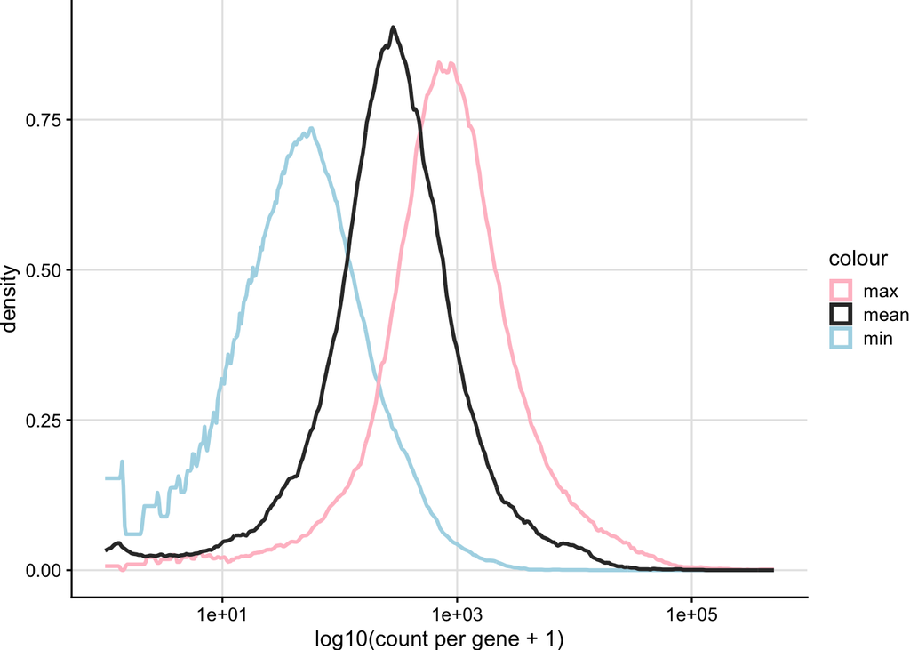

```r
count_stats_bygene <-
  counts_all %>%
  as.matrix() %>%
  tibble(gene = rownames(.),
         count_min = rowMins(.),
         count_mean = rowMeans(.),
         count_max = rowMaxs(.)) %>%
  select( - ".") # removes pipe behaviour leading to inclusion of "."

genelist_mincount_10 <-
  count_stats_bygene %>%
  filter(count_min >= 10) %>%
  pull(gene)

ggplot(data = count_stats_bygene) +
  geom_density(aes(x=count_min + 1, colour = "min"),
               size = 1, kernel = "rectangular") +
  geom_density(aes(x=count_max + 1, colour = "max"),
               size = 1, kernel = "rectangular") +
  geom_density(aes(x=count_mean + 1, colour = "mean"),
               size = 1, kernel = "rectangular") +
  scale_colour_manual(values = c("min" = "lightblue",
                                 "mean" = "grey20",
                                 "max" = "pink")) +
  scale_x_log10("log10(count per gene + 1)")
```

## Select GCT-dependent log2FC at each timepoint

```r
# Create a tidy data frame that contains only the GCT-dependent log2FC
# in a helpful format for plotting
deseq_df_GCT <-
  biobroom::tidy.DESeqDataSet(dds_all) %>%
  mutate(GCT = term %>%
           stringr::str_remove("GCT") %>%
           factor(levels = GCT_levels)) %>%
  select(GCT, gene, baseMean, log2estimate = estimate) %>%
  group_by(gene) %>%
  mutate(log2FC = log2estimate - mean(log2estimate)) %>%
  ungroup()

# restrict to genes with mincount 10
deseq_df_GCT_mincount_10 <-
  deseq_df_GCT %>%
  filter(gene %in% genelist_mincount_10)

# check we retained all the levels
unique(deseq_df_GCT$GCT)
```

```
##  [1] del_R_120  del_R_240  del_R_30   del_RS_120 del_RS_240 del_RS_30
##  [7] del_Y_0    WT_R_120   WT_R_240   WT_R_30    WT_RS_120  WT_RS_240
## [13] WT_RS_30   WT_Y_0
## 14 Levels: WT_Y_0 WT_R_30 WT_RS_30 WT_R_120 WT_RS_120 WT_R_240 ... del_RS_240
```

## Sanity-check: Did we get the log2FC right for a favourite gene?

CNAG_06917 / TSA3 is strongly GAT201-dependent.

```r
deseq_df_GCT %>%
  filter(gene == "CNAG_06917")
```

```
## # A tibble: 14 × 5
##    GCT        gene       baseMean log2estimate log2FC
##    <fct>      <chr>         <dbl>        <dbl>  <dbl>
##  1 del_R_120  CNAG_06917    3405.         8.27 -0.615
##  2 del_R_240  CNAG_06917    3405.        11.3   2.44
##  3 del_R_30   CNAG_06917    3405.         6.44 -2.45
##  4 del_RS_120 CNAG_06917    3405.         8.24 -0.649
##  5 del_RS_240 CNAG_06917    3405.        10.8   1.89
##  6 del_RS_30  CNAG_06917    3405.         6.24 -2.65
##  7 del_Y_0    CNAG_06917    3405.         5.24 -3.65
##  8 WT_R_120   CNAG_06917    3405.        11.4   2.53
##  9 WT_R_240   CNAG_06917    3405.        14.3   5.40
## 10 WT_R_30    CNAG_06917    3405.         5.89 -3.00
## 11 WT_RS_120  CNAG_06917    3405.        10.6   1.67
## 12 WT_RS_240  CNAG_06917    3405.        14.1   5.25
## 13 WT_RS_30   CNAG_06917    3405.         5.60 -3.29
## 14 WT_Y_0     CNAG_06917    3405.         6.03 -2.87
```

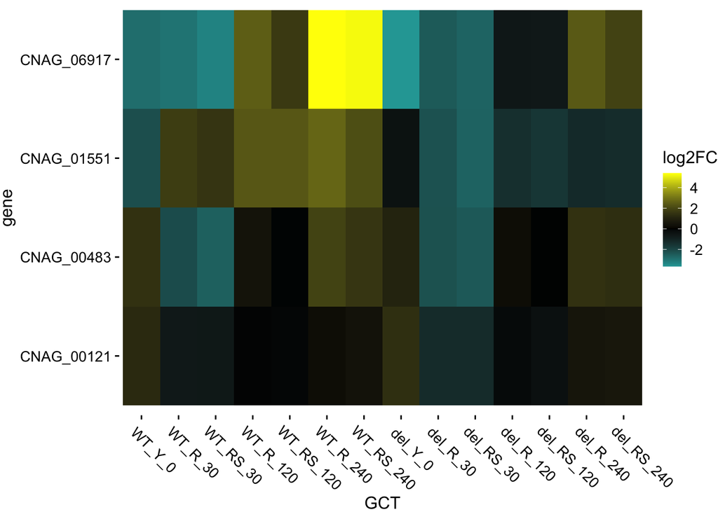

```r
ggplot(data = deseq_df_GCT %>%
  filter(gene %in% c("CNAG_00483", "CNAG_00121", "CNAG_06917", "CNAG_01551")),
  aes(x = GCT, fill = log2FC, y = gene)) +
  geom_tile() +
  scale_fill_gradient2(low = "cyan", mid = "black", high = "yellow") +
  theme(axis.text.x = element_text(angle = -45, hjust = 0.1),
        panel.grid.major = element_blank(),
        axis.line = element_blank())
```

## Calculate gene expression hierarchical clusters

Here we restrict to genes with at least 10 counts in each sample. This list was calculated earlier as `genelist_mincount_10`.

This avoids a problem with numeric errors in calculations for all genes, that probably came from genes with low/zero counts.

```r
log2FC_GCT_m10_wide <-
  deseq_df_GCT_mincount_10  %>%
  select(gene,GCT, log2FC) %>%
  pivot_wider(id_cols = gene, names_from = GCT, values_from = log2FC) %>%
  select(c("gene", all_of(GCT_levels)))

# order genes according to mean value at 0min, as far as clustering allows
preferred_gene_ordering <-
  log2FC_GCT_m10_wide %>%
  dplyr::mutate(Y_0_mean = ( WT_Y_0 + del_Y_0 ) / 2 ) %>%
  dplyr::pull(Y_0_mean)

distcort <- function(x) {
  as.dist(1 - cor(t(x)))
}

hclust_log2FC <-
  log2FC_GCT_m10_wide %>%
  select(-gene) %>%
  as.matrix() %>%
  set_rownames(log2FC_GCT_m10_wide$gene) %>%
  # head(n= 100) %>%
  distcort() %>%
  hclust(method = "average") %>%
  reorder(wts = preferred_gene_ordering)
```

## Plot clustering dendrogram by itself

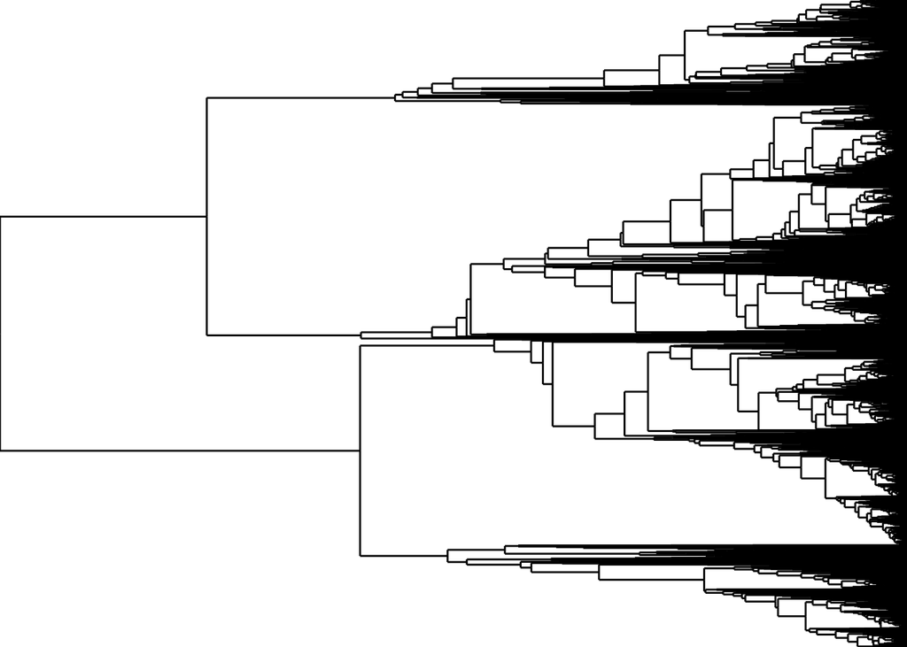

```r
plot_dendrogram_log2FC_m10 <-
  ggdendrogram(hclust_log2FC,
               rotate = TRUE,
               labels = FALSE) +
  theme_void() +
  scale_y_reverse() +
  coord_flip(expand = c(0,0), clip = "off")
plot_dendrogram_log2FC_m10
```

## Plot the log2 fold-change in same order as clustering dendrogram

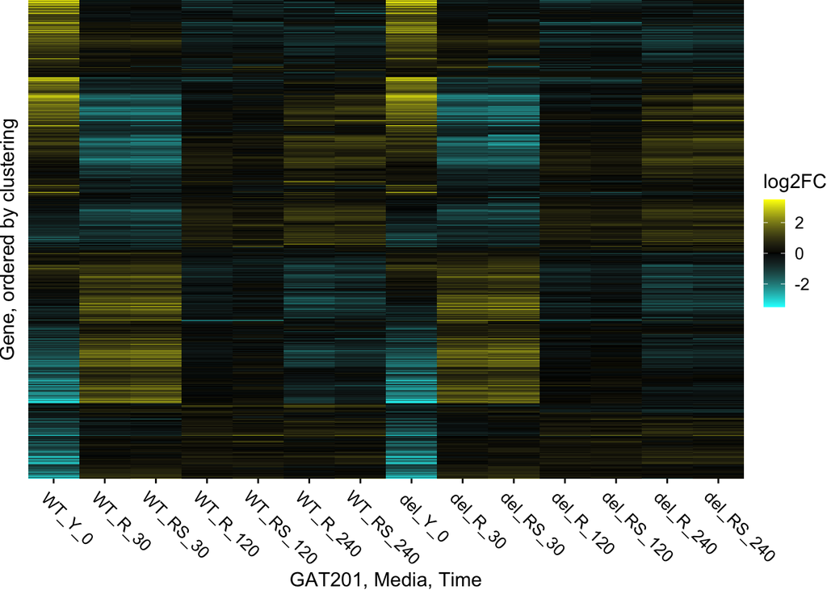

```r
deseq_df_GCT_mincount_10_dorder <-
  deseq_df_GCT_mincount_10 %>%
  mutate(gene_dorder =
           factor(gene,
                  levels = log2FC_GCT_m10_wide$gene[hclust_log2FC$order],
                  ordered = TRUE)
         )

plot_log2FC_m10_dorder <-
  ggplot(data = deseq_df_GCT_mincount_10_dorder,
         aes(x = GCT, fill = log2FC, y = gene_dorder)) +
  geom_tile() +
  scale_fill_gradient2(low = "cyan", mid = "black", high = "yellow",
                       limits = c(-3.5, 3.5), oob = scales::squish) +
  coord_cartesian(expand = c(0,0), clip = "off") +
  theme(axis.text.x = element_text(angle = -45, hjust = 0.1),
        panel.grid.major = element_blank(),
        axis.line = element_blank(),
        axis.text.y = element_blank(), axis.ticks.y = element_blank()) +
  labs(x = "GAT201, Media, Time",
       y = "Gene, ordered by clustering")

plot_log2FC_m10_dorder
```

## Make a nicer x-axis for sample labels

This section programs up x-axis labels split up by GAT201, Time, Serum.

It’s ugly code to get a pretty result.

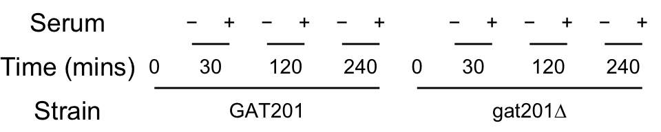

```r
GCT_df <-
  tibble(GCT = as_factor(GCT_levels),
                 x = as.numeric(GCT)) %>%
  separate(GCT, c("GAT201","Condition","Time"), remove = FALSE) %>%
  mutate(Time = as.integer(Time),
         Serum = factor(Condition,
                        levels = c("R","RS"),
                        labels = c("−", "+")),
         GAT201 = GAT201 %>%
           str_replace("del", "gat201∆") %>%
           str_replace( "WT", "GAT201"),
         GAT201Serum = paste(GAT201, Condition, sep = "_") %>%
           str_replace("RS", "+") %>%
           str_replace("R|Y", "−") %>%
           as_factor()
         )

GCT_time_df <- GCT_df %>%
  group_by(GAT201,Time) %>%
  summarise(xmean = mean(x), xmin = min(x), xmax = max(x))

GCT_GAT201_df <- GCT_df %>%
  group_by(GAT201) %>%
  summarise(xmean = mean(x), xmin = min(x), xmax = max(x))

plot_nice_GCT_labels <-
  ggplot(data = GCT_df) +
  geom_text(aes(x = x, label = Serum), y = 3) +
  geom_text(data = GCT_time_df, aes(x = xmean, label = Time), y = 2) +
  geom_segment(data = GCT_time_df,
               aes(x = xmin, xend = xmax), y = 2.5, yend = 2.5) +
  geom_text(data = GCT_GAT201_df, aes(x = xmean, label = GAT201), y = 1) +
  geom_segment(data = GCT_GAT201_df,
               aes(x = xmin, xend = xmax), y = 1.5, yend = 1.5) +
  scale_y_continuous(limits = c(0.5,3.5),
                     breaks = c(1,2,3),
                     labels = c("Strain", "Time (mins)", "Serum")) +
  scale_x_continuous(limits = c(0.5, max(GCT_df$x + 0.5))) +
  coord_cartesian(expand = c(0,0), clip = "off") +
  theme_nothing() +
  theme(axis.text.y = element_text())

plot_nice_GCT_labels
```

```r
# the next bit plots the y-axis labels as their own ggplot, right-aligned
# so that we can get everything to align nicely in the plot_grid later
plot_nice_GCT_yaxis <-
  ggplot(data = tibble(y = c(1,2,3),
                     label = c("Strain", "Time", "Serum")),
         aes(y=y, label = label)) +
  geom_text(hjust = 1, x = 1) +
  coord_cartesian(xlim = c(0, 1), ylim = c(0.5, 3.5),
                  expand = c(0,0), clip = "off")  +
  theme_nothing()
```

# Combined plot of dendrogram and heatmap

This is figure 3C of manuscript. It combines the previous plot panels into a single plot, showing the dendrogram aligned with the clustered heatmap, and with nice x-axis labels.

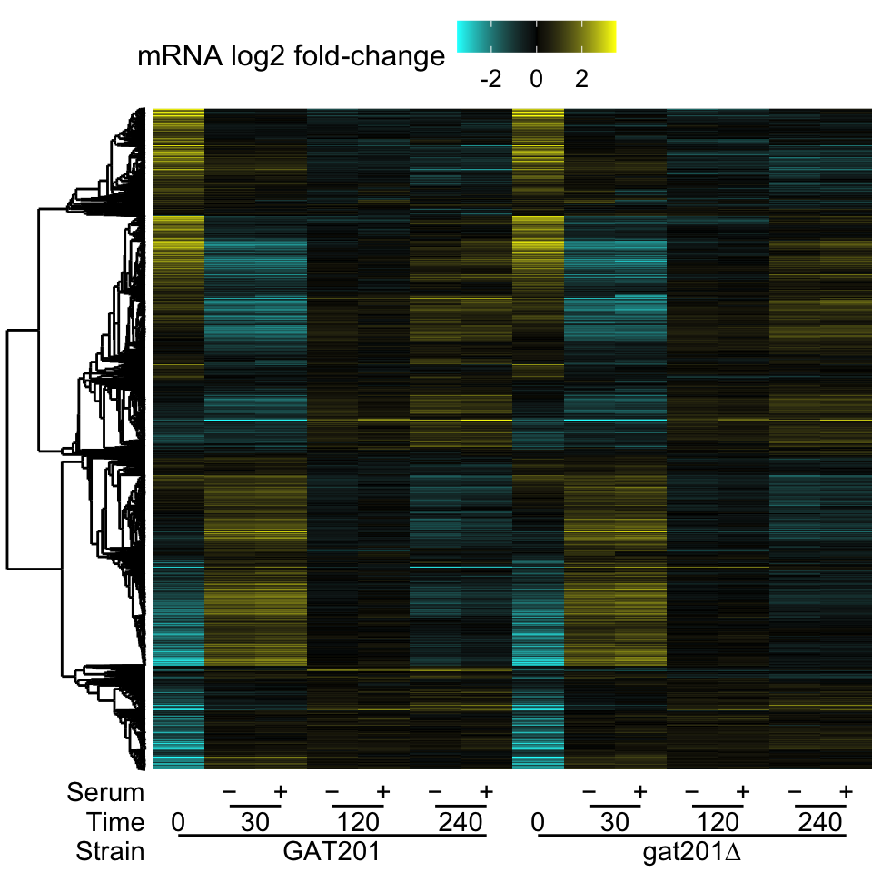

```r
plot_dh_nolegend <-
  plot_grid(plot_dendrogram_log2FC_m10,
          plot_log2FC_m10_dorder +
            theme(axis.title.y = element_blank(),
                  axis.title.x = element_blank(),
                  axis.text.x = element_blank(),
                  axis.ticks.x = element_blank(),
                  legend.position = "none"),
          plot_nice_GCT_yaxis,
          plot_nice_GCT_labels + theme(axis.text.y = element_blank()),
          ncol = 2,
          align = "hv",
          rel_widths = c(1,5),
          rel_heights = c(7,1))

plot_grid(get_legend(plot_log2FC_m10_dorder +
                       labs(fill = "mRNA log2 fold-change") +
                       theme(legend.box.margin = margin(0, 0, 0, 2,
                                                        unit = "cm"),
                             legend.position = "top")),
          plot_dh_nolegend,
          ncol = 1,
          rel_heights = c(1,7))
```

```r
ggsave(filename = here::here("results",
                             "clustered_heatmap_GAT201SerumTime.svg"),
       width = 5, height = 5)
```

### Highlight select genes on y-axis.

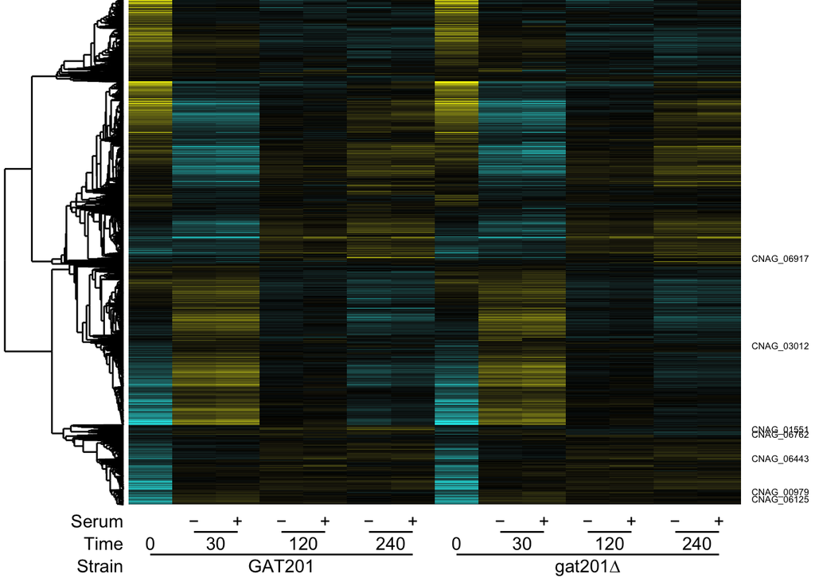

```r
select_genes <- c("CNAG_03012", "CNAG_06443", "CNAG_01551", "CNAG_06917", "CNAG_06125", "CNAG_06762", "CNAG_00979")

select_genes_dorder <-
  tibble( gene = log2FC_GCT_m10_wide$gene,
          gene_dorder = factor(log2FC_GCT_m10_wide$gene,
                  levels = log2FC_GCT_m10_wide$gene[hclust_log2FC$order],
                  ordered = TRUE),
          y = as.integer(gene_dorder)) %>%
  dplyr::filter( gene %in% select_genes )

plot_select_genes_dorder <-
  ggplot(data = select_genes_dorder)  +
  # geom_segment(colour = "grey50",
  #              x = 0, xend = 0,
  #              y = 1, yend = nrow(log2FC_GCT_m10_wide)) +
  geom_text(aes(y = y, label = gene),
            x = 0, size = 2) +
  coord_cartesian(xlim = c(-0.5,0.5),
                  ylim = c(1, nrow(log2FC_GCT_m10_wide)),
                  expand = c(0,0), clip = "off") +
  theme_nothing()

plot_grid(plot_dendrogram_log2FC_m10,
          plot_log2FC_m10_dorder +
            theme(axis.title.y = element_blank(),
                  axis.title.x = element_blank(),
                  axis.text.x = element_blank(),
                  axis.ticks.x = element_blank(),
                  legend.position = "none"),
          plot_select_genes_dorder,
          plot_nice_GCT_yaxis,
          plot_nice_GCT_labels + theme(axis.text.y = element_blank()),
          NULL,
          ncol = 3,
          align = "hv",
          rel_widths = c(1,5,0.6),
          rel_heights = c(7,1))
```

```r
# ggsave(filename = here::here("results",
#                              "clustered_heatmap_GAT201SerumTime_plus.svg"),
#        width = 5.5, height = 5)
```

### Extract and plot clusters

```r
make_clustered_df <- function(k = 2,
                              names_df = log2FC_GCT_m10_wide,
                              hclust_results = hclust_log2FC) {
      tibble(gene = names_df$gene,
         gene_dorder =
           factor(gene,
                  levels = names_df$gene[hclust_results$order],
                  ordered = TRUE),
         y = as.integer(gene_dorder),
         cluster = hclust_results %>%
           cutree(k = k) %>%
           factor())
}

get_cluster_from_clustered_df <- function(gene_bait,
                                          clustered_df,
                                          output = c("list", "df")) {
  # find cluster containing the gene_bait (gene of interest)
  cluster_number <- clustered_df %>%
    dplyr::filter(gene == gene_bait) %>%
    dplyr::pull(cluster)
  # return all of that cluster
  clustered_df_filtered <-
    clustered_df %>%
    dplyr::filter(cluster == cluster_number)
  if (output == "df") {
    return(clustered_df_filtered)
  } else if (output == "list") {
    return(clustered_df_filtered$gene)
  }
}

make_cluster_with_gene <- function(gene_bait,
                                   k = 2,
                                   names_df = log2FC_GCT_m10_wide,
                                   hclust_results = hclust_log2FC,
                                   output = c("list", "df")) {
  clustered_df <-
    make_clustered_df(k = k,
                      names_df = names_df,
                      hclust_results = hclust_results)
  get_cluster_from_clustered_df(gene_bait, clustered_df)
}

plot_clustered_genelist <-
  function(genelist, data = deseq_df_GCT_mincount_10_dorder) {
    ggplot(data = data %>%
             dplyr::filter(gene %in% genelist),
           aes(x = GCT, fill = log2FC, y = gene_dorder)) +
      geom_tile() +
      scale_fill_gradient2(low = "cyan", mid = "black", high = "yellow",
                           limits = c(-3, 3), oob = scales::squish) +
      scale_y_discrete(breaks = genelist#, labels = names(genelist)
                       ) +
      coord_cartesian(expand = c(0,0), clip = "off") +
      theme(axis.text.x = element_text(angle = -45, hjust = 0.1),
            panel.grid.major = element_blank())

  }
```

```r
genecluster_CQS1 <- make_cluster_with_gene(gene = "CNAG_03012", k = 100)

plot_genecluster_CQS1 <- plot_clustered_genelist(genecluster_CQS1)


genecluster_SSA1 <- make_cluster_with_gene(gene = "CNAG_06443", k = 100)

genecluster_TEF1_k100 <- make_cluster_with_gene(gene = "CNAG_06125", k = 100)
all.equal(genecluster_SSA1,genecluster_TEF1_k100)
```

```
## [1] TRUE
```

```r
genecluster_TEF1 <- make_cluster_with_gene(gene = "CNAG_06125", k = 500)
genecluster_CTR4 <- make_cluster_with_gene(gene = "CNAG_00979", k = 500)
all.equal(genecluster_TEF1,genecluster_CTR4)
```

```
## [1] TRUE
```

```r
plot_genecluster_TEF1 <- plot_clustered_genelist(genecluster_TEF1)


genecluster_TSA3 <- make_cluster_with_gene(gene = "CNAG_06917", k = 100)

plot_genecluster_TSA3 <- plot_clustered_genelist(genecluster_TSA3)


genecluster_GAT201 <- make_cluster_with_gene(gene = "CNAG_01551", k = 100)

plot_genecluster_GAT201 <- plot_clustered_genelist(genecluster_GAT201)
```

```r
hclust_colour_df_grouped <-
  tibble(gene = log2FC_GCT_m10_wide$gene,
         gene_dorder =
           factor(gene,
                  levels = log2FC_GCT_m10_wide$gene[hclust_log2FC$order],
                  ordered = TRUE),
         y = as.integer(gene_dorder),
         cluster_select = fct_collapse(gene,
                                       CQS1   = genecluster_CQS1,
                                       # HSP    = genecluster_SSA1,
                                       GAT201 = genecluster_GAT201,
                                       TSA3   = genecluster_TSA3,
                                       RPs    = genecluster_TEF1,
                                       other_level = "other") %>%
           forcats::fct_recode(NULL = "other")
         ) %>%
  group_by(cluster_select) %>%
  summarise(n = n(), ymin = min(y), ymax = max(y), ymean = mean(y))
```

Note that we do not use these clusters later, except to check where the select genes are in the heatmap.

## Plot example genes for main figure

This is figure 3D of manuscript.

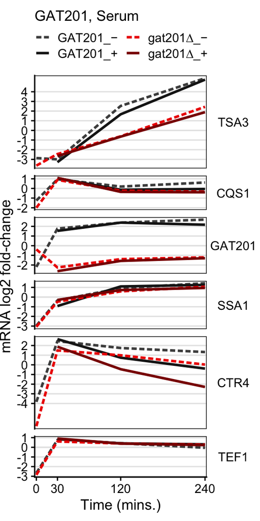

```r
plot_mygenes_facet <- function(mygenes,
                               mygenenames,
                               deseq_df = deseq_df_GCT,
                               meta_df = GCT_df,
                               facet_option = c("stack_free", "grid_fixed")) {
  mygenes_df <-
    tibble(gene  = mygenes %>% as_factor(),
           name = mygenenames %>% as_factor()) %>%
    dplyr::left_join(deseq_df) %>%
    dplyr::left_join(meta_df, by = "GCT")

    plot_out <-
  ggplot(data = mygenes_df,
         aes(x = Time, y = log2FC,
             colour = GAT201Serum, group = GAT201Serum,
             linetype = GAT201Serum)) +
    geom_hline(yintercept = 0, size = 0.5, colour = "grey90") +
    geom_line(size = 1) +
    scale_y_continuous("mRNA log2 fold-change",
                       # limits = ylimits,
                       breaks = seq(-4,4),
                       expand = c(0.01,0.2)) +
    scale_x_continuous("Time (mins.)",
                       breaks = c(0,30,120,240),
                       expand = c(0.01,0.01)) +
    scale_colour_manual(
      "GAT201, Serum",
      values = c("GAT201_−" = "grey30",
                 "GAT201_+" = "grey10",
                 "gat201∆_−" = "red2",
                 "gat201∆_+" = "red4")) +
    scale_linetype_manual(
      "GAT201, Serum",
      values = c("GAT201_−" = "21",
                 "GAT201_+" = "solid",
                 "gat201∆_−" = "21",
                 "gat201∆_+" = "solid")) +
    guides(colour = guide_legend(
      title.position = "top",
      ncol = 2)) +
    panel_border(color = "black", size = 0.5) +
    theme(strip.text.y = element_text(angle = 0),
          legend.position = "top",
          plot.margin = unit(c(0.1, 0, 0.1, 0), "in"),
          panel.grid.major.x = element_blank())
    if (facet_option == "stack_free") {
    plot_out <- plot_out +
      facet_grid(name~., scales = "free", space = "free")
  } else if (facet_option == "wrap_fixed") {
    plot_out <- plot_out +
      facet_wrap(~ name)
  }
  return(plot_out)
}

plot_mygenes_facet(
  mygenes =  c("CNAG_06917", "CNAG_03012", "CNAG_01551", "CNAG_06443", "CNAG_00979", "CNAG_06125"),
  mygenenames = c("TSA3", "CQS1", "GAT201", "SSA1", "CTR4", "TEF1")
)
```

```r
ggsave(filename = here::here("results",
                             "log2FC_line_multipanel_6select.svg"),
       width = 2.5, height = 5.8)
```

## Plot 30 example genes for supplementary figure

This is figure S8 of manuscript.

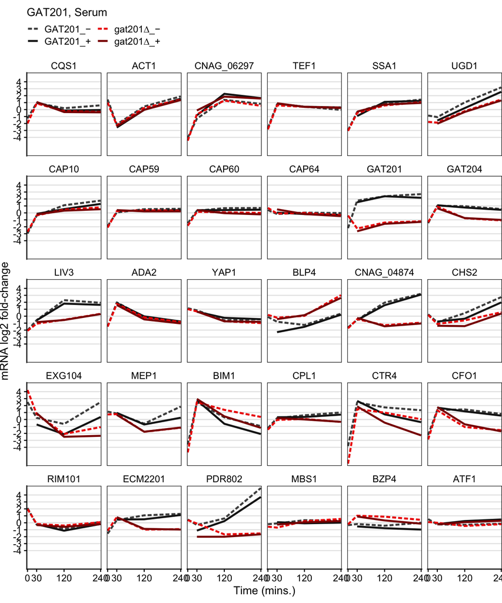

```r
my30genes <-
  here::here("input_annotation", "CryptoWakeup_30genes.txt") %>%
  read_tsv()

plot_mygenes_facet(
  mygenes =  my30genes$GeneID,
  mygenenames = my30genes$GeneName,
  facet_option = "wrap_fixed"
)
```

```r
ggsave(filename = here::here("results", "log2FC_line_30genes.png"),
       width = 7.5, height = 9.5)
```

# Serum-dependent gene expression analysis with DESeq2

This first uses the matrix of counts and the samplesheet information table to construct the DESeq2 data object, then immediately runs the analysis.

```r
samplesheet_RPMIboth <-
  dplyr::filter(samplesheet, Time > 0)

counts_RPMIboth <-
      dplyr::select(counts, samplesheet_RPMIboth$SampleID) %>%
      magrittr::set_rownames(counts$Geneid)

dds_serum <- DESeqDataSetFromMatrix(
    countData = counts_RPMIboth,
    colData = samplesheet_RPMIboth,
    design = ~ GAT201_Time + Serum:GAT201_Time - 1 ) %>%
  DESeq()

dds_serum
```

```
## class: DESeqDataSet
## dim: 6795 48
## metadata(1): version
## assays(4): counts mu H cooks
## rownames(6795): CNAG_00002 CNAG_00003 ... CNAG_14001 CNAG_14002
## rowData names(62): baseMean baseVar ... deviance maxCooks
## colnames(48): 2 3 ... 55 56
## colData names(14): SampleID BioRep ... GCT sizeFactor
```

```r
resultsNames(dds_serum)
```

```
##  [1] "GAT201_TimeWT_30"            "GAT201_TimeWT_120"
##  [3] "GAT201_TimeWT_240"           "GAT201_Timedel_30"
##  [5] "GAT201_Timedel_120"          "GAT201_Timedel_240"
##  [7] "GAT201_TimeWT_30.SerumYes"   "GAT201_TimeWT_120.SerumYes"
##  [9] "GAT201_TimeWT_240.SerumYes"  "GAT201_Timedel_30.SerumYes"
## [11] "GAT201_Timedel_120.SerumYes" "GAT201_Timedel_240.SerumYes"
```

## Select serum-dependent log2FC at each timepoint

```r
coefnames_serum <- c("GAT201_TimeWT_30.SerumYes", "GAT201_TimeWT_120.SerumYes",
                      "GAT201_TimeWT_240.SerumYes",
                      "GAT201_Timedel_30.SerumYes", "GAT201_Timedel_120.SerumYes",
                      "GAT201_Timedel_240.SerumYes")

# Create a tidy data frame that contains only the GAT201-dependent log2FC
# in a helpful format for plotting
deseq_df_GT_vsserum <-
  biobroom::tidy.DESeqDataSet(dds_serum) %>%
  dplyr::filter(term %in% coefnames_serum) %>%
  dplyr::mutate(GAT201_Time = term %>%
           stringr::str_remove("GAT201_Time") %>%
           stringr::str_remove(".SerumYes") %>%
           factor(levels = GAT201_Time_levels)) %>%
  dplyr::left_join(gene_info_df,
                   by = "gene") %>%
  dplyr::select(GAT201_Time,
                gene,
                geneName,
                baseMean,
                log2FC = estimate,
                stderror,
                padj = p.adjusted)

# check we retained all the levels
unique(deseq_df_GT_vsserum$GAT201_Time)
```

```
## [1] del_120 del_240 del_30  WT_120  WT_240  WT_30
## Levels: WT_0 WT_30 WT_120 WT_240 del_0 del_30 del_120 del_240
```

## Count the number of DEGs up and down at each Condition and Time

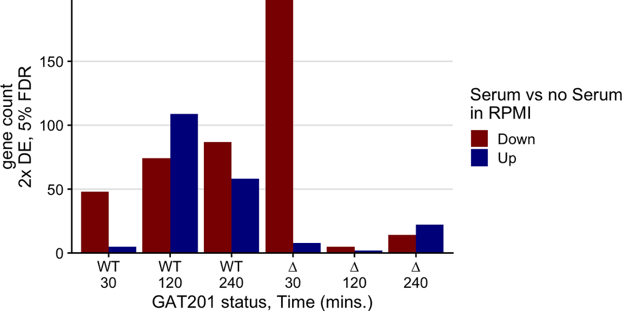

```r
countDEGs_GT_vsserum <-
  deseq_df_GT_vsserum %>%
  group_by(GAT201_Time) %>%
  summarise(Up   = sum(log2FC > 1  & padj < 0.05, na.rm = TRUE),
            Down = sum(log2FC < -1 & padj < 0.05, na.rm = TRUE))

## prototype plot; not run but included as an example.
# ggplot(data = countDEGs_CT_vsGAT201,
#        aes(x = GAT201_Time)) +
#   geom_col(aes(y = Up))

countDEGs_GT_vsserum_long <-
  countDEGs_GT_vsserum %>%
  pivot_longer(cols = c(Up,Down),
               names_to = "Direction",
               values_to = "DEG_count")

barplot_countDEGs_GT_vsserum <-
  ggplot(data = countDEGs_GT_vsserum_long,
         aes(x = GAT201_Time, y = DEG_count, fill = Direction)) +
  geom_col(position = "dodge") +
  scale_fill_manual("Serum vs no Serum\nin RPMI",
                    values = c("Down" = "darkred",
                               "Up" = "darkblue")) +
  scale_y_continuous("gene count\n2x DE, 5% FDR", expand = c(0,0)) +
  scale_x_discrete("GAT201 status, Time (mins.)",
                   breaks = GAT201_Time_levels,
                   labels = GAT201_Time_levels_vprint) +
  theme(panel.grid.major.x = element_blank())

barplot_countDEGs_GT_vsserum
```

## Calculate serum-dependent DEG lists for both strains at each timepoint

Write output to tab-separated txt files, in order of log2 fold-change as calculated above. Both as DEG dfs including log2 fold-change and p-values, also as lists of gene Ids only.

First for wild-type cells

```r
deseq_df_WT_30_vsSerum <-
  dplyr::filter(deseq_df_GT_vsserum,
                GAT201_Time == "WT_30") %>%
  dplyr::select(-GAT201_Time)

write_DEGdflist(deseq_df_WT_30_vsSerum, write_list = FALSE)

DEGdf_WT_30_vsSerum_up2x_FDR5 <-
  dplyr::filter(deseq_df_GT_vsserum,
                GAT201_Time == "WT_30",
                log2FC > 1, padj < 0.05) %>%
  dplyr::select(-GAT201_Time) %>%
  dplyr::arrange(desc(log2FC))

write_DEGdflist(DEGdf_WT_30_vsSerum_up2x_FDR5)

DEGdf_WT_30_vsSerum_down2x_FDR5 <-
  dplyr::filter(deseq_df_GT_vsserum,
                GAT201_Time == "WT_30",
                log2FC < -1, padj < 0.05) %>%
  dplyr::select(-GAT201_Time) %>%
  dplyr::arrange(log2FC)

write_DEGdflist(DEGdf_WT_30_vsSerum_down2x_FDR5)


deseq_df_WT_120_vsSerum <-
  dplyr::filter(deseq_df_GT_vsserum,
                GAT201_Time == "WT_120") %>%
  dplyr::select(-GAT201_Time)

write_DEGdflist(deseq_df_WT_120_vsSerum, write_list = FALSE)

DEGdf_WT_120_vsSerum_up2x_FDR5 <-
  dplyr::filter(deseq_df_GT_vsserum,
                GAT201_Time == "WT_120",
                log2FC > 1, padj < 0.05) %>%
  dplyr::select(-GAT201_Time) %>%
  dplyr::arrange(desc(log2FC))

write_DEGdflist(DEGdf_WT_120_vsSerum_up2x_FDR5)

DEGdf_WT_120_vsSerum_down2x_FDR5 <-
  dplyr::filter(deseq_df_GT_vsserum,
                GAT201_Time == "WT_120",
                log2FC < -1, padj < 0.05) %>%
  dplyr::select(-GAT201_Time) %>%
  dplyr::arrange(log2FC)

write_DEGdflist(DEGdf_WT_120_vsSerum_down2x_FDR5)


deseq_df_WT_240_vsSerum <-
  dplyr::filter(deseq_df_GT_vsserum,
                GAT201_Time == "WT_240") %>%
  dplyr::select(-GAT201_Time)

write_DEGdflist(deseq_df_WT_240_vsSerum, write_list = FALSE)

DEGdf_WT_240_vsSerum_up2x_FDR5 <-
  dplyr::filter(deseq_df_GT_vsserum,
                GAT201_Time == "WT_240",
                log2FC > 1, padj < 0.05) %>%
  dplyr::select(-GAT201_Time) %>%
  dplyr::arrange(desc(log2FC))

write_DEGdflist(DEGdf_WT_240_vsSerum_up2x_FDR5)

DEGdf_WT_240_vsSerum_down2x_FDR5 <-
  dplyr::filter(deseq_df_GT_vsserum,
                GAT201_Time == "WT_240",
                log2FC < -1, padj < 0.05) %>%
  dplyr::select(-GAT201_Time) %>%
  dplyr::arrange(log2FC)

write_DEGdflist(DEGdf_WT_240_vsSerum_down2x_FDR5)
```

Then for deltaGAT201 cells

```r
deseq_df_gat201del_30_vsSerum <-
  dplyr::filter(deseq_df_GT_vsserum,
                GAT201_Time == "del_30") %>%
  dplyr::select(-GAT201_Time)

write_DEGdflist(deseq_df_gat201del_30_vsSerum, write_list = FALSE)

DEGdf_gat201del_30_vsSerum_up2x_FDR5 <-
  dplyr::filter(deseq_df_GT_vsserum,
                GAT201_Time == "del_30",
                log2FC > 1, padj < 0.05) %>%
  dplyr::select(-GAT201_Time) %>%
  dplyr::arrange(desc(log2FC))

write_DEGdflist(DEGdf_gat201del_30_vsSerum_up2x_FDR5)

DEGdf_gat201del_30_vsSerum_down2x_FDR5 <-
  dplyr::filter(deseq_df_GT_vsserum,
                GAT201_Time == "del_30",
                log2FC < -1, padj < 0.05) %>%
  dplyr::select(-GAT201_Time) %>%
  dplyr::arrange(log2FC)

write_DEGdflist(DEGdf_gat201del_30_vsSerum_down2x_FDR5)


deseq_df_gat201del_120_vsSerum <-
  dplyr::filter(deseq_df_GT_vsserum,
                GAT201_Time == "del_120") %>%
  dplyr::select(-GAT201_Time)

write_DEGdflist(deseq_df_gat201del_120_vsSerum, write_list = FALSE)

DEGdf_gat201del_120_vsSerum_up2x_FDR5 <-
  dplyr::filter(deseq_df_GT_vsserum,
                GAT201_Time == "del_120",
                log2FC > 1, padj < 0.05) %>%
  dplyr::select(-GAT201_Time) %>%
  dplyr::arrange(desc(log2FC))

write_DEGdflist(DEGdf_gat201del_120_vsSerum_up2x_FDR5)

DEGdf_gat201del_120_vsSerum_down2x_FDR5 <-
  dplyr::filter(deseq_df_GT_vsserum,
                GAT201_Time == "del_120",
                log2FC < -1, padj < 0.05) %>%
  dplyr::select(-GAT201_Time) %>%
  dplyr::arrange(log2FC)

write_DEGdflist(DEGdf_gat201del_120_vsSerum_down2x_FDR5)


deseq_df_gat201del_240_vsSerum <-
  dplyr::filter(deseq_df_GT_vsserum,
                GAT201_Time == "del_240") %>%
  dplyr::select(-GAT201_Time)

write_DEGdflist(deseq_df_gat201del_240_vsSerum, write_list = FALSE)

DEGdf_gat201del_240_vsSerum_up2x_FDR5 <-
  dplyr::filter(deseq_df_GT_vsserum,
                GAT201_Time == "del_240",
                log2FC > 1, padj < 0.05) %>%
  dplyr::select(-GAT201_Time) %>%
  dplyr::arrange(desc(log2FC))

write_DEGdflist(DEGdf_gat201del_240_vsSerum_up2x_FDR5)

DEGdf_gat201del_240_vsSerum_down2x_FDR5 <-
  dplyr::filter(deseq_df_GT_vsserum,
                GAT201_Time == "del_240",
                log2FC < -1, padj < 0.05) %>%
  dplyr::select(-GAT201_Time) %>%
  dplyr::arrange(log2FC)

write_DEGdflist(DEGdf_gat201del_240_vsSerum_down2x_FDR5)
```

## Notes on genes at 4h

```r
DEGdf_gat201del_240_vsSerum_down2x_FDR5
```

```
## # A tibble: 14 × 6
##    gene       geneName   baseMean log2FC stderror     padj
##    <chr>      <chr>         <dbl>  <dbl>    <dbl>    <dbl>
##  1 CNAG_02005 CNAG_02005     49.2  -2.44    0.337 6.27e-10
##  2 CNAG_00979 CTR4        20403.   -2.32    0.299 2.81e-11
##  3 CNAG_00895 ZIP1         3287.   -1.95    0.226 4.29e-14
##  4 CNAG_04877 CNAG_04877     95.5  -1.83    0.540 1.92e- 2
##  5 CNAG_03398 ZIP2          358.   -1.78    0.296 1.17e- 6
##  6 CNAG_07334 FRE4         5875.   -1.62    0.221 4.73e-10
##  7 CNAG_02775 BIM1        29986.   -1.57    0.230 7.39e- 9
##  8 CNAG_05392 ZAP104        284.   -1.41    0.194 5.75e-10
##  9 CNAG_03007 CNAG_03007     96.9  -1.38    0.271 6.79e- 5
## 10 CNAG_02225 EXG104         72.6  -1.25    0.317 4.17e- 3
## 11 CNAG_05867 CNAG_05867    969.   -1.21    0.244 1.05e- 4
## 12 CNAG_00537 CNAG_00537     83.5  -1.12    0.326 1.74e- 2
## 13 CNAG_04857 CNAG_04857     45.1  -1.09    0.332 2.41e- 2
## 14 CNAG_02008 OVA1          557.   -1.05    0.242 1.29e- 3
```

- CNAG_00979, CTR4 Copper uptake transporter
- CNAG_02775, BIM1 BCS (copper-starvation) inducible membrane protein
- CNAG_00895, ZIP1 zinc transporter
- CNAG_03398, ZIP2 zinc transporter
- CNAG_03007, hypothetical protein
- CNAG_02005, hypothetical protein
- CNAG_03453, CipC-like antibiotic response protein

## Volcano plot, serum-dependent DGE in wild-type at 4 hours.

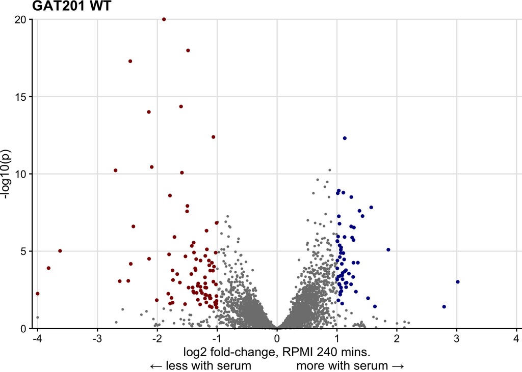

```r
volcano_WT_240_vsSerum <-
  ggplot(data = dplyr::filter(deseq_df_GT_vsserum,
                              GAT201_Time == "WT_240"),
         aes(x = log2FC, y = -log10(padj)) ) +
  geom_point(size = 0.5, colour = "grey50") +
  geom_point(data = DEGdf_WT_240_vsSerum_up2x_FDR5,
             size = 1, colour = "darkblue") +
  geom_point(data = DEGdf_WT_240_vsSerum_down2x_FDR5,
             size = 1, colour = "darkred") +
  scale_y_continuous("-log10(p)",
                     limits = c(0,20), expand = c(0,0),
                     oob=scales::squish) +
  scale_x_continuous("log2 fold-change, RPMI 240 mins.\n← less with serum             more with serum →",
                     breaks = -5:5,
                     limits = c(-4,4), expand = c(0.01,0.01),
                     oob = scales::squish) +
  coord_cartesian(clip = "off") +
  labs(title = "GAT201 WT")

volcano_WT_240_vsSerum
```

## Volcano plot, serum-dependent DGE in gat201∆ at 4 hours.

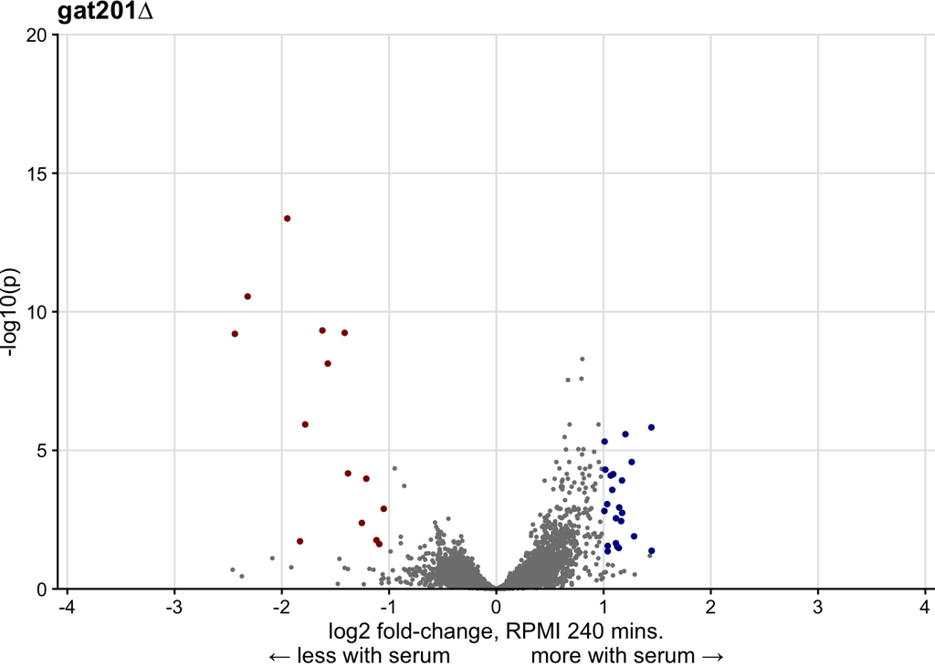

```r
volcano_gat201del_240_vsSerum <-
  ggplot(data = dplyr::filter(deseq_df_GT_vsserum,
                              GAT201_Time == "del_240"),
         aes(x = log2FC, y = -log10(padj)) ) +
  geom_point(size = 0.5, colour = "grey50") +
  geom_point(data = DEGdf_gat201del_240_vsSerum_up2x_FDR5,
             size = 1, colour = "darkblue") +
  geom_point(data = DEGdf_gat201del_240_vsSerum_down2x_FDR5,
             size = 1, colour = "darkred") +
  scale_y_continuous("-log10(p)",
                     limits = c(0,20), expand = c(0,0),
                     oob=scales::squish) +
  scale_x_continuous("log2 fold-change, RPMI 240 mins.\n← less with serum             more with serum →",
                     breaks = -5:5,
                     limits = c(-4,4), expand = c(0.01,0.01),
                     oob = scales::squish) +
  coord_cartesian(clip = "off") +
  labs(title = "gat201∆")

volcano_gat201del_240_vsSerum
```

## Multipanel plot showing Serum affects expression of a small set of transcripts.

This is Figure S9 of the manuscript.

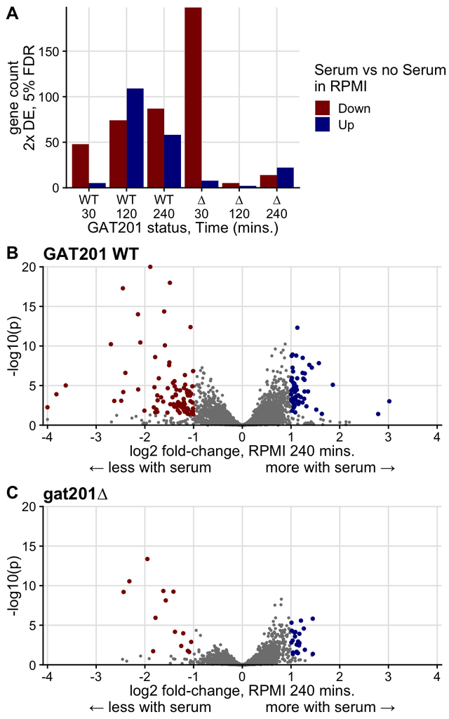

```r
theme_gridplot <-
  theme_cowplot(font_size = 12, font_family = "Arial") +
  theme(panel.grid.major = element_line(colour = "grey90", size = 0.5))

multipanel_serumdependence <-
  plot_grid(barplot_countDEGs_GT_vsserum + theme_gridplot,
            volcano_WT_240_vsSerum  + theme_gridplot,
            volcano_gat201del_240_vsSerum  + theme_gridplot,
            ncol = 1, labels = "AUTO"
  )

multipanel_serumdependence
```

```r
ggsave(filename = here::here("results", "serum_dependence_count_volcano2x.png"),
       plot = multipanel_serumdependence,
       width = 5, height = 8)
```